# Math 421 - Midterm

## III. Predictive Models

Continue with the data from part I. Make sure you do not have any missing values in the data. Use the follows as the target and input variables:

*Target Variable*: Create the target variable taking value of

- `low` if the total charge of a patient (`tot`) is smaller than the median of the total charge, and
- `high` otherwise.

*Input Variables*:

- “age”,“sex”,“raceethn”,“provider”,“moa”,“mod”,“admtype”,“campus”, ‘los’
1. Use `filter` function to filter out rows where `raceethn==''` or `admtype==''`. Make sure all the categorical variables are factor, numeric variables are numeric. Set Training : Testing Split = 10 : 90

```r
# Creating target variable
df$target <- case_when(df$tot < median(df$tot) ~ 'low',
                       TRUE ~ 'High')

# Creating df to use for modeling
model_df = subset(df,select = c(age, sex, raceethn, provider, moa, mod, admtype, campus, los, target))

# Filtering out rows where raceethn or admtype == '' and converting categorical variables to factors
model_df <- model_df %>% filter(raceethn != '' | admtype != '') %>%
  mutate(age = as.numeric(age),
         sex = as.factor(sex),
         raceethn = as.factor(raceethn),
         provider = as.factor(provider),
         moa = as.factor(moa),
         mod = as.factor(mod),
         admtype = as.factor(admtype),
         campus = as.factor(campus),
         los = as.numeric(los),
         target = as.factor(target))

# Splitting data
set.seed(2020)
splitIndex <- createDataPartition(model_df$target, p = 0.10, list = FALSE)
df_train <- model_df[ splitIndex,]
df_test <- model_df[ -splitIndex,]
```

2. Train a decision tree using `rpart`. Plot the decision tree. Plot the variable importance ranked by the tree.

```r
# Creating a decision tree with max depth of 3
tree_1 <- rpart(target ~ ., data = df_train,
                 control = rpart.control(maxdepth = 3))

# Calculating the accuracy of the model on the testing data
pred_1 <- predict(tree_1, df_test, type = 'class')

cm_1 <- confusionMatrix(data = pred_1, reference = df_test$target)
cm_1$overall[1]
```

```
##  Accuracy
## 0.7704526
```

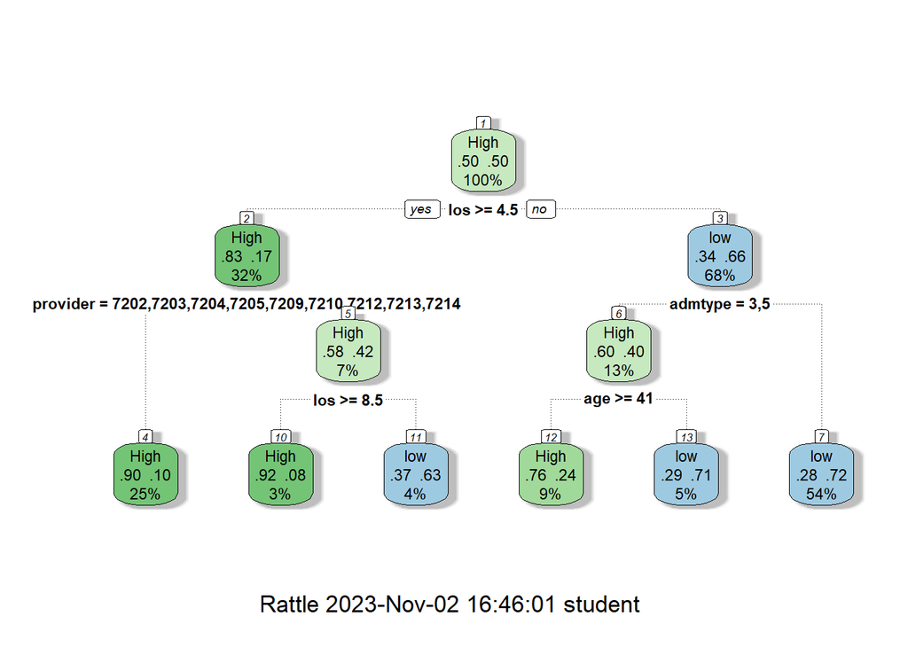

```r
# Plotting the tree
fancyRpartPlot(tree_1)
```

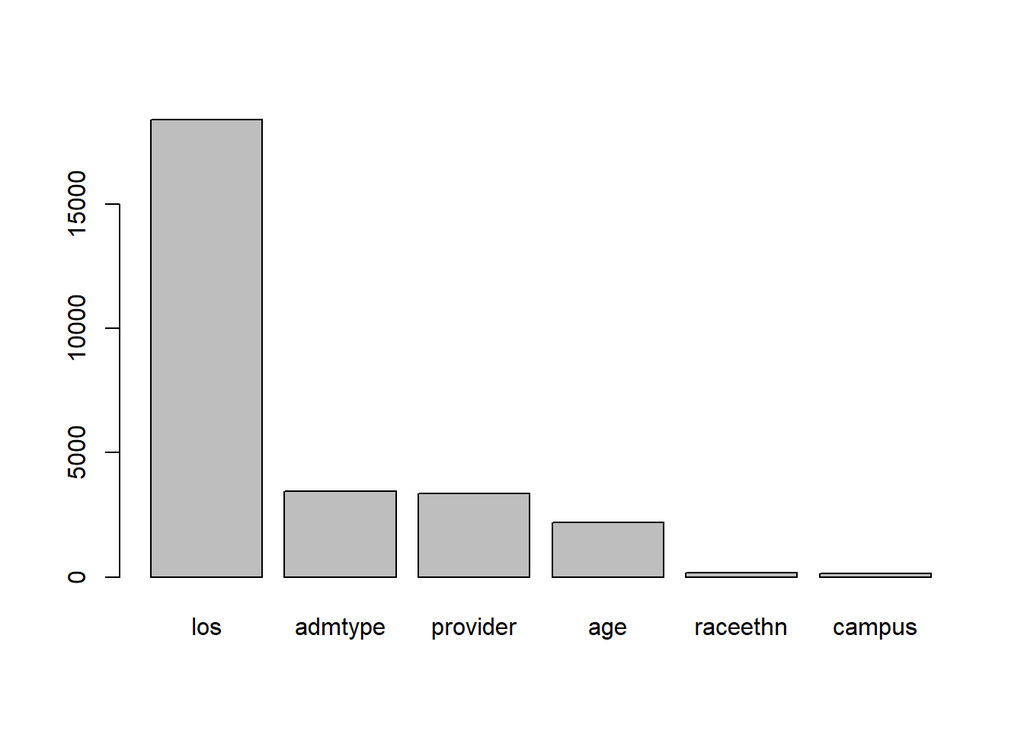

```r
# Plotting the variable importance by the tree
barplot(tree_1$variable.importance)
```

3. Using caret for this question. Set `Training Control` to be: Use Cross-Validation of 5 folds across all models. Train & tune at least 2 different models (i.e. two different values for `method=` in the train function of caret). Plot the hyper-parameter tuning plots for each model.

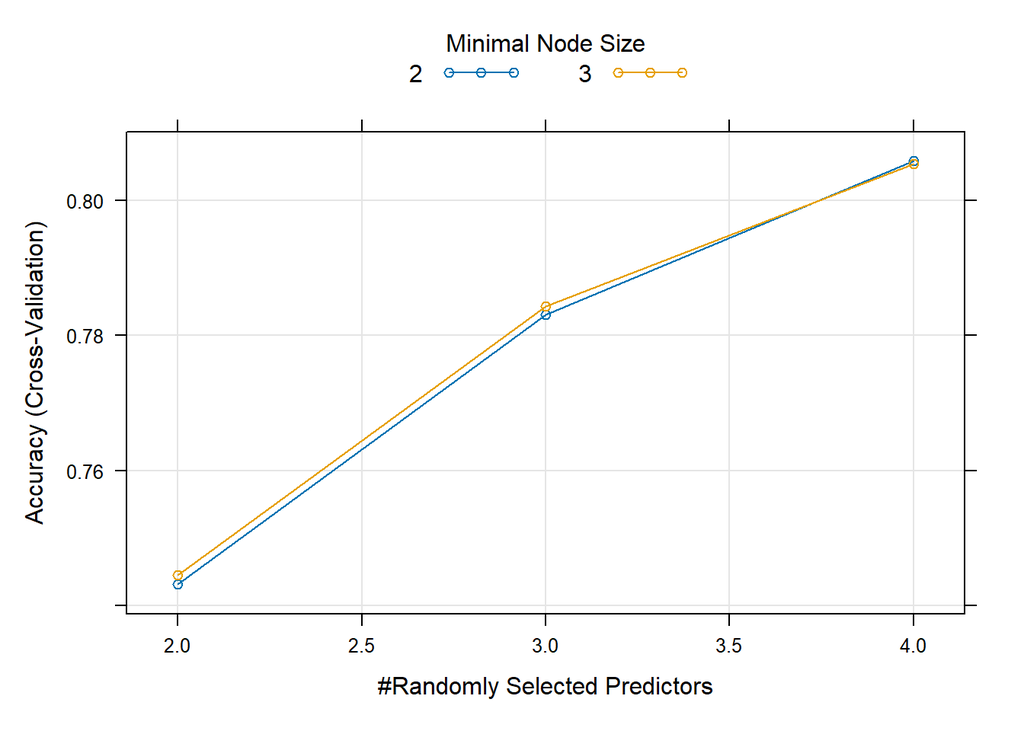

```r
# Setting Training Control to be a Cross-Validation of 5 folds
trControl = trainControl(method = "cv", number = 5)

# Tuning a forest
tuneGrid = expand.grid(mtry = 2:4,
                       splitrule = c('gini'),
                       min.node.size = c(2:3))

forest1 <- train(target~., data=df_train, method = "ranger", trControl = trControl, tuneGrid = tuneGrid)

# Plotting hyper-parameter tuning plot for forest
plot(forest1)
```

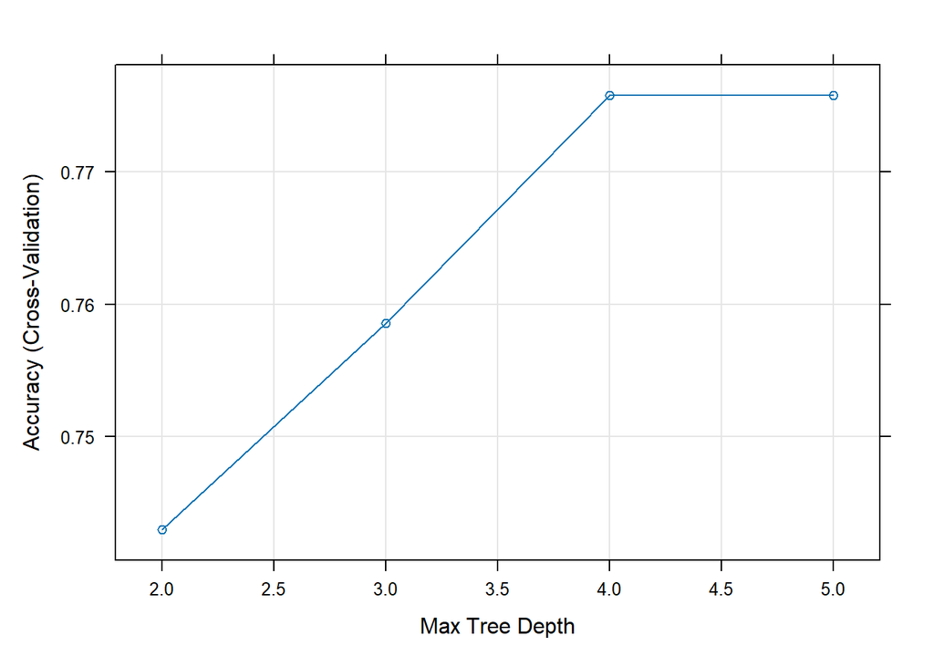

```r
# Tuning a tree
tuneGrid = expand.grid(maxdepth = 2:5)

tree2 <- train(target~., data=df_train,
                                method = "rpart2",
                                trControl = trControl,
                                tuneGrid = tuneGrid)

# Plotting hyper-parameter tuning plot for tree
plot(tree2)
```

4. Plot the comparison of the models in 3.

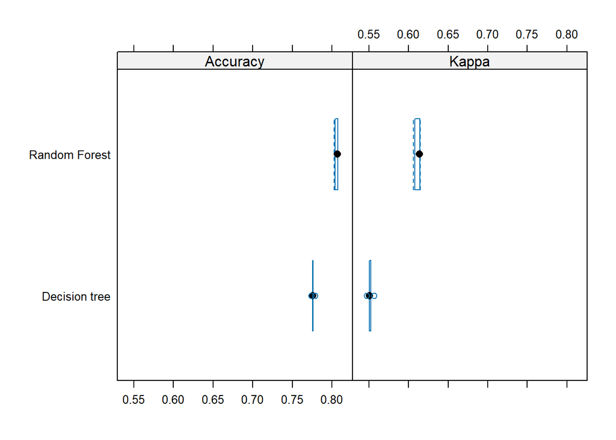

```r
results <- resamples(list('Random Forest' = forest1,
                          'Decision tree' = tree2))
bwplot(results)
```

5. What is your final selection for the model? Test the accuracy of your final model on the test data.

```r
# Although it has a wider variance, I am selecting the random forest as my final model because its middle 50% (including its median accuracy score) is greater than that of the decision tree.

forest1_pred <- predict(forest1, df_test)
```

```
## Predicting.. Progress: 30%. Estimated remaining time: 1 minute, 11 seconds.
## Predicting.. Progress: 62%. Estimated remaining time: 37 seconds.
## Predicting.. Progress: 93%. Estimated remaining time: 6 seconds.
## Aggregating predictions.. Progress: 78%. Estimated remaining time: 8 seconds.
```

```r
forest1_cm <- confusionMatrix(data = forest1_pred, reference = df_test$target)
forest1_cm$overall[1]
```

```
##  Accuracy
## 0.8066632
```

6. Create another `target` variable (binary), decide the input variables and redo 1 to 5.

```r
# I decided to see if I a model would be able to use the given columns to predict the gender of a patient
df$target <- df$sexdesc

# Creating df to use for modeling
model_df2 = subset(df,select = c(age, raceethn, provider, moa, mod, admtype, campus, los, target))

# Filtering out rows where raceethn or admtype == '' and converting categorical variables to factors
model_df2 <- model_df2 %>% filter(raceethn != '' | admtype != '') %>%
  mutate(age = as.numeric(age),
         raceethn = as.factor(raceethn),
         provider = as.factor(provider),
         moa = as.factor(moa),
         mod = as.factor(mod),
         admtype = as.factor(admtype),
         campus = as.factor(campus),
         los = as.numeric(los),
         target = as.factor(target))

# Splitting data
set.seed(2020)
splitIndex <- createDataPartition(model_df2$target, p = 0.10, list = FALSE)
df_train2 <- model_df2[ splitIndex,]
df_test2 <- model_df2[ -splitIndex,]
```

```r
# Creating a decision tree with rpart
tree_2 <- rpart(target ~ ., data = df_train2,
                 control = rpart.control(maxdepth = 3))

# Calculating the accuracy of the model on the testing data
pred_2 <- predict(tree_2, df_test2, type = 'class')

cm_2 <- confusionMatrix(data = pred_2, reference = df_test2$target)
cm_2$overall[1]
```

```
## Accuracy
## 0.579718
```

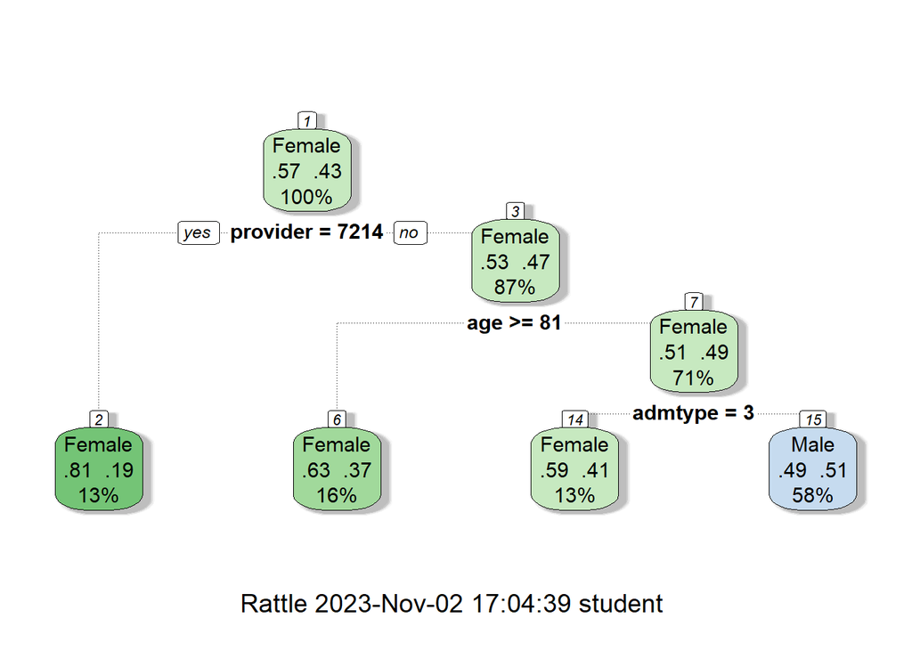

```r
# Plotting the tree
fancyRpartPlot(tree_2)
```

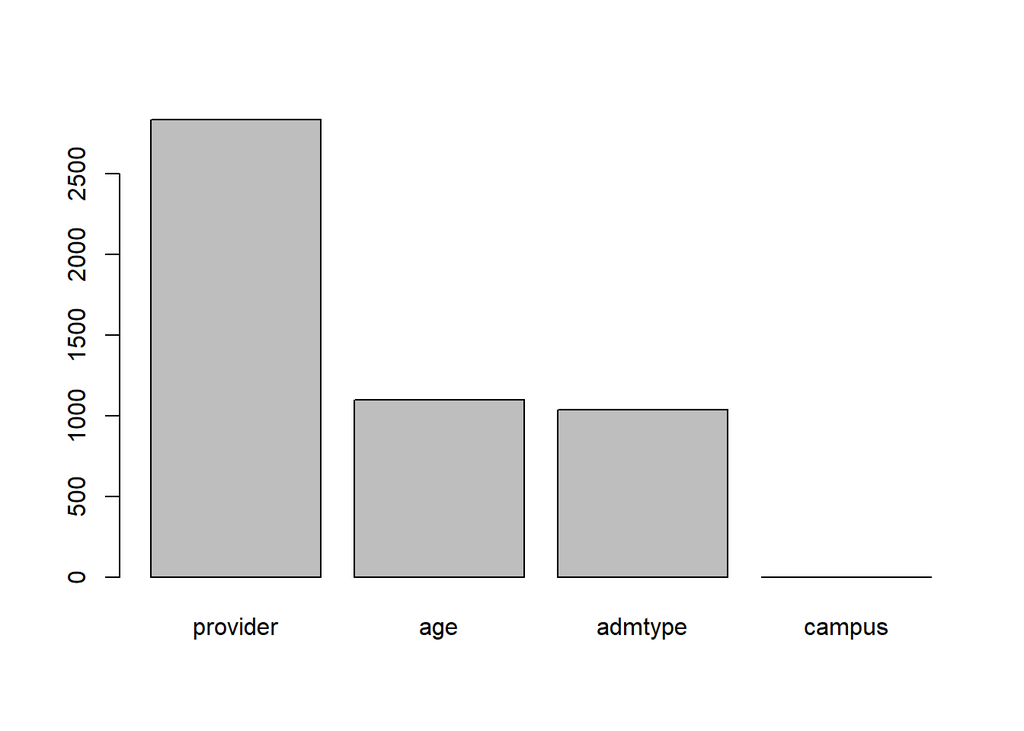

```r
# Plotting the variable importance by the tree
barplot(tree_2$variable.importance)
```

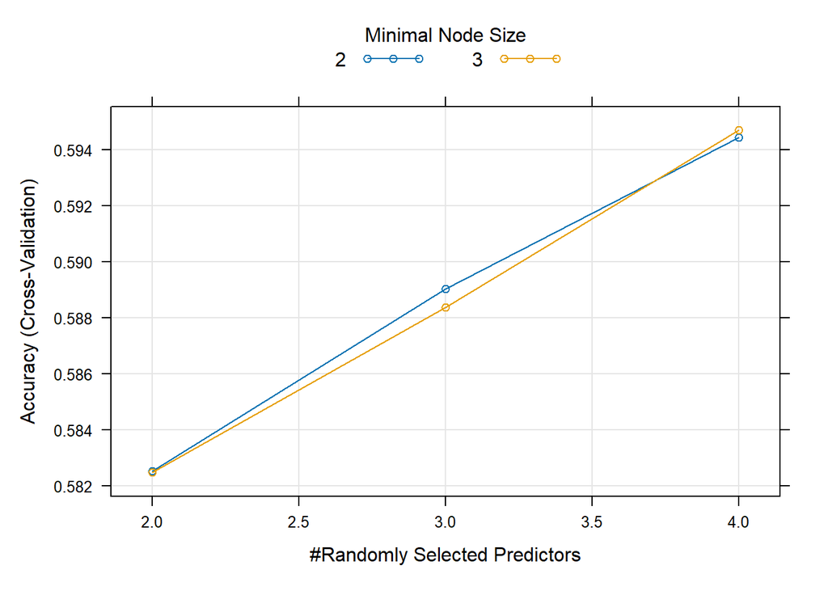

```r
# Setting Training Control to be a Cross-Validation of 5 folds
trControl = trainControl(method = "cv", number = 5)

# Tuning a forest
tuneGrid = expand.grid(mtry = 2:4,
                       splitrule = c('gini'),
                       min.node.size = c(2:3))

forest2 <- train(target~., data=df_train2, method = "ranger", trControl = trControl, tuneGrid = tuneGrid)

# Plotting hyper-parameter tuning plot for forest
plot(forest2)
```

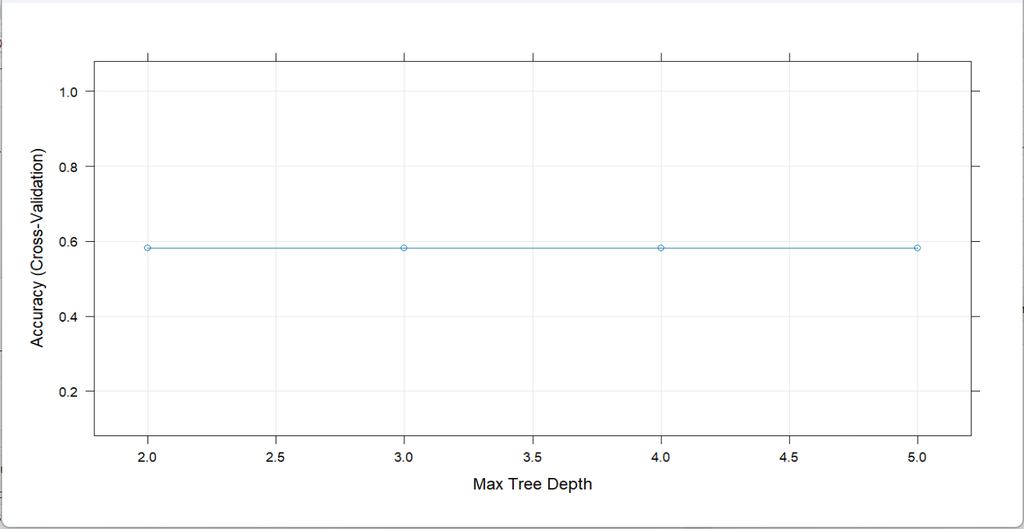

```r
#################################  NOTE  #################################################
# I was able to run the block of code below without issue, however when I went to knit the doc, it was giving me an error and I found that R was acting strange because only when I knit the file, the code below was giving an error that all Accuracy and Kappa metric values were missing. Upon further research, I checked to see if I had missing data or if I forgot to identify any variables as factors or numerics for df_train2, however I did everything correct and could not figure out why this block would not knit. Given this, I decided to comment out this block and provided a screenshot of the plot for tree3 below this block.
##########################################################################################

# Tuning a tree
#tuneGrid = expand.grid(maxdepth = 2:5)

#tree3 <- train(target~., data=df_train2,
#                                method = "rpart2",
#                                trControl = trControl,
#                                tuneGrid = tuneGrid)

# Plotting hyper-parameter tuning plot for tree
#plot(tree3)
```

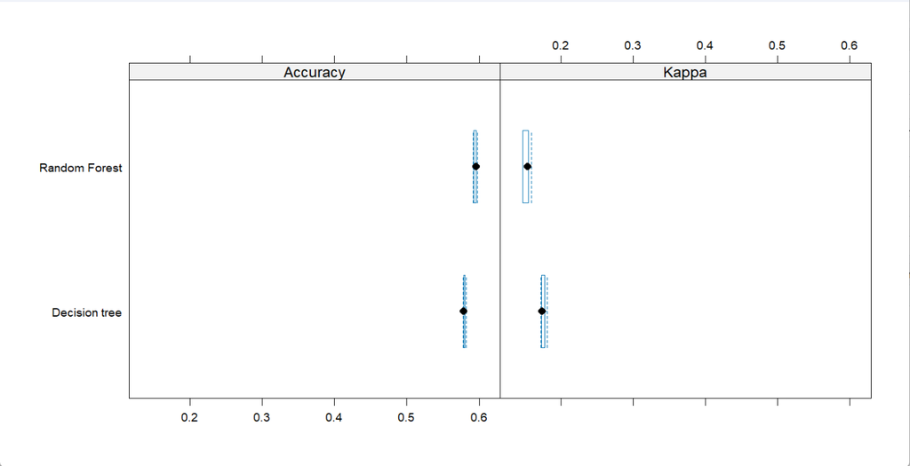

```r
#####################################  NOTE  #############################################
# Unfortunately, since I had to comment out the code in the block above, I also have to comment out this block as the 'tree3' object will not be defined. Thus, I have also included a screenshot of the results from this block below.
##########################################################################################


#results <- resamples(list('Random Forest' = forest2,
#                          'Decision tree' = tree3))
#bwplot(results)
```

```r
# Here, it is fairly clear that the random forest is the better model as the entirety of its accuracy scores appear to be greater than or equal to the median accuracy of the decision tree.

forest2_pred <- predict(forest2, df_test2)
```

```
## Predicting.. Progress: 58%. Estimated remaining time: 22 seconds.
```

```r
forest2_cm <- confusionMatrix(data = forest2_pred, reference = df_test2$target)
forest2_cm$overall[1]
```

```
##  Accuracy
## 0.5963618
```

7. Write a paragraph to summarize the section and give your comments on the results.

```r
# For the first model, I was not surprised to see that length of stay was the most important variable in terms of predicting whether or not the total charge was going to be low or high (as longer stays means that a patient would be utilizing more hospital services and thus would increase their total charge). It was also not surprising to see that the random forest outperformed the decision tree in terms of accuracy as the forest is more complex and could get a better sense of the data in training. On the testing data, the forest seemed to be decent with an accuracy of 80.67%, however it could likely still be improved. If the run time wasn't so long, I would be interested to see if we could find a higher accuracy by testing more hyper-parameters.

# For the second model, I was interested to see that the rpart tree considered provider to be the most important variable for predicting gender. Once again, it was also not surprising to see the random forest outperform the decision tree in terms of accuracy. I also was not overly surprised that the forest did not perform well on the testing data (around 60% accuracy), as I did not think the input variables would do a great job at predicting the patient's gender.
```